# Labels on `geom_col` (and `geom_bar`)

Brendan O’Dowd

2022-06-07

## Labels in the middle of columns

Let’s make a stacked bar chart with labels inside each of the bars which show the value of that bar. We’ll use the Titanic dataset as an example. The Titanic dataset is not actually a dataframe but a different structure called a ‘table’, but we can easily convert it to a dataframe using `data.frame()`. Here we are counting the number of people in each class who did and did not survive. We then make a column for each class, each having two rectangles, one for `Survived == "Yes"` and one for `Survived == "No"`.

To add the labels we use `geom_text()`, and the content of the labels is specified using `label = count` within the `aes` mapping function. But if we left it at that the plot would look crap! Within the `geom_text` function I specify `position = position_stack(vjust = 0.5)`. This tells the labels that they should be stacked, and that they should be placed halfway up the column. If we removed the `vjust = 0.5` then the label would appear exactly on top of the column.

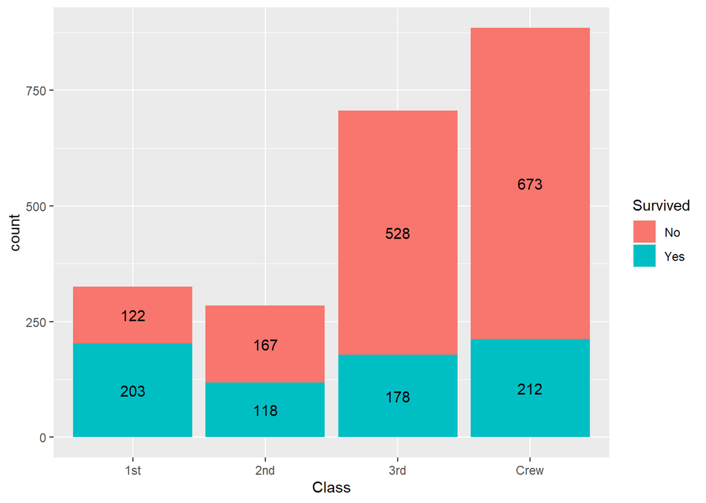

```r
library(tidyverse)

data_for_plot <- Titanic %>% data.frame() %>%
  group_by(Class , Survived) %>%
  summarise(count = sum(Freq))

ggplot(data_for_plot, aes(x=Class, y = count , fill = Survived , label = count)) +
  geom_col() +
  geom_text(position = position_stack(vjust = 0.5))
```

If you want some kind of special formatting on the labels (like percent of thousand comma separators) you can either

1. make a new variable which is a character version of `count` that has your formatting and use that in the `label =` part, or
2. wrap the numeric value in the formatting function you want directly in the `label =` part.

Below I’ll show both examples. The output is the same so I’ll only show it once. I’ll load the scales package which provides the convenient formatting functions `percent()` and `comma()`.

```r
library(scales)
```

```r
# Option A, creating a new column which is a formatted version of pct

data_for_plot <- Titanic %>% data.frame() %>%
  group_by(Class , Survived) %>%
  summarise(count = sum(Freq)) %>%
  mutate(pct = count/sum(count)) %>%
  mutate(pct_label = percent(pct))  # < key part

ggplot(data_for_plot, aes(x=Class ,
                          y=pct ,
                          fill=Survived ,
                          label = pct_label)) + # < key part
  geom_col() +
  geom_text(position = position_stack(vjust = 0.5)) +
  scale_y_continuous(labels = percent)
```

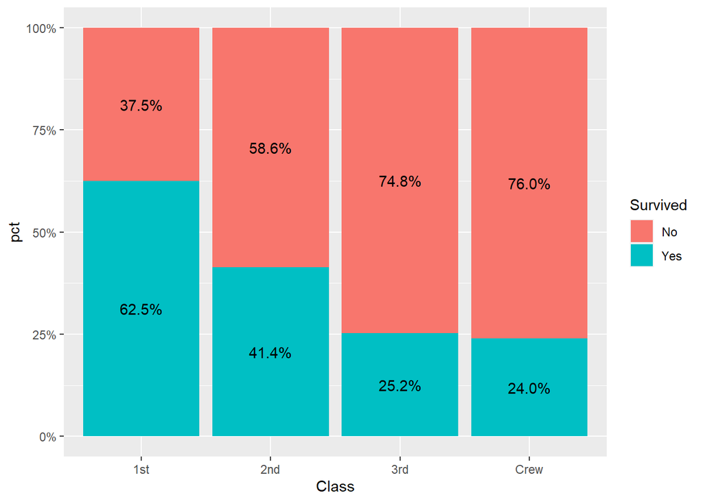

```r
# Option B, wrapping pct in the formatting function pct directly
# in the 'label = ' bit.

data_for_plot <- Titanic %>% data.frame() %>%
  group_by(Class , Survived) %>%
  summarise(count = sum(Freq)) %>%
  mutate(pct = count/sum(count))

ggplot(data_for_plot, aes(x=Class ,
                          y=pct ,
                          fill=Survived ,
                          label = percent(pct))) + # < key part
  geom_col() +
  geom_text(position = position_stack(vjust = 0.5)) +
  scale_y_continuous(labels = percent)
```

Two notes on this.

- Firstly I’ve added `scale_y_continuous(labels = percent)` so that the y scale goes from 0% to 100% rather than from 0 to 1. Note that `percent` here refers to the `percent` function from the scales package, but the brackets must not be used.
- Secondly, you can control the number of decimal places in the formatted percentage using the additional argument `accuracy`, so for example `percent(0.051, accuracy=1)` produces 5%, while `percent(0.051, accuracy=0.1)` produces 5.1%.

## Labels at the end of columns

Let’s say we have a normal, non-stacked column chart, and want the labels to stick out at the top of each column. We can do that by adding a `nudge_y` value to `geom_text()`. The parameters `nudge_x` and `nudge_y` move the labels relative to their default location which is the top centre of each column, and the units for these parameters are the units of the axes themselves. The value of 40 here is found through a little bit of trial and error.

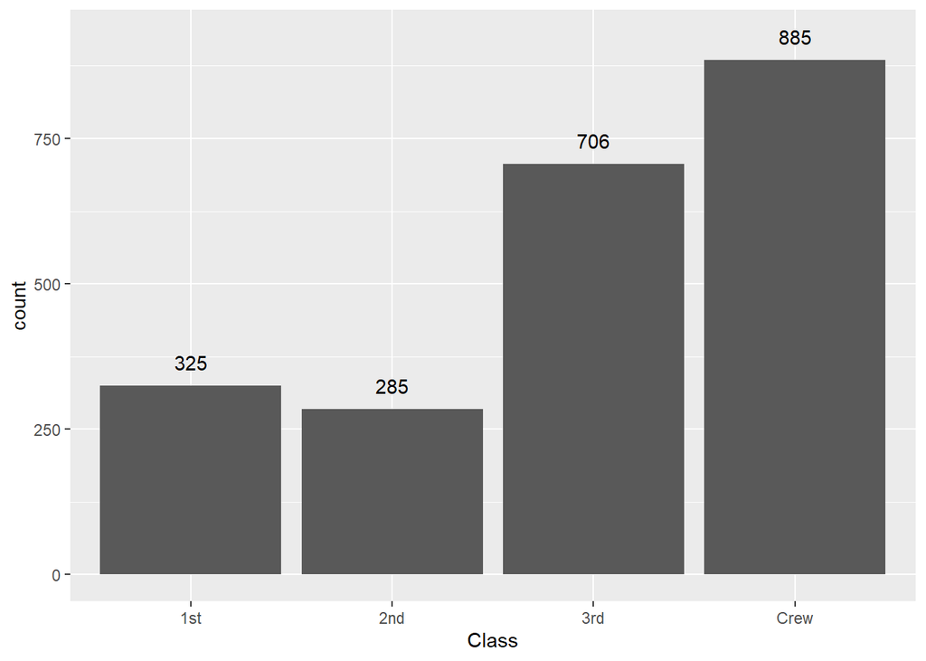

```r
data_for_plot <- Titanic %>% data.frame() %>%
  group_by(Class ) %>%
  summarise(count = sum(Freq))

ggplot(data_for_plot, aes(x=Class , y=count , label=count)) +
  geom_col() +
  geom_text(nudge_y = 40)
```

Another option is to use parameters `hjust` and `vjust`, but you should be aware of some differences:

#### Differences between `nudge_x`/`nudge_y` and `hjust`/`vjust`

- The plot area expands to accomodate movement of labels through `nudge_x` and `nudge_y`, but not with `hjust` and `vjust`. If a label disappears off the plot when using `vjust` you will probably need to adjust the axis limits.
- `nudge_x` and `nudge_y` cannot be used in combination with `position =` geom_text, but `hjust` and `vjust` can.
- The units of `nudge_x` and `nudge_y` are the units of the respective axes, while I think the units of `hjust` and `vjust` relate to the size of the text item itself.
- Positive values of `nudge_x` and `nudge_y` move text right and up, while positive values of `hjust` and `vjust` move text left and down.
- If you flip the coordinates using `+ coord_flip()` then the values of `nudge_x` and `nudge_y` would remain unchanged but you would need to reconfigure `hjust` and `vjust` since they relate to the plot area and not the axes.
- `hjust` and `vjust` can take values of `"top"`, `"bottom"`, `"left"`, and `"right"`. However for the purposes of positioning text labels I don’t find `"top"` and `"bottom"` useful because there is zero offset; the text touches the column border.

What about a grouped column chart with text labels popping out the top? In that case, we need to move the text outside the top of the bar **and** offset the text to the left and right so they are not sitting on top of each other. We can achieve the latter left-right-offset by using `position = position_dodge()` within the `geom_text()` function. The `width` value of 0.9 seems to work well for most charts of this type with a discrete x-axis. However, when it comes to moving the text outside the top of the bar we cannot use `nudge_y` in combination with `position =` as mentioned above. Instead we have to use `vjust`. Note that I’ve had to adjust the y-axis limits using `ylim()` because the plot area doesn’t expand for text moved using `vjust`.

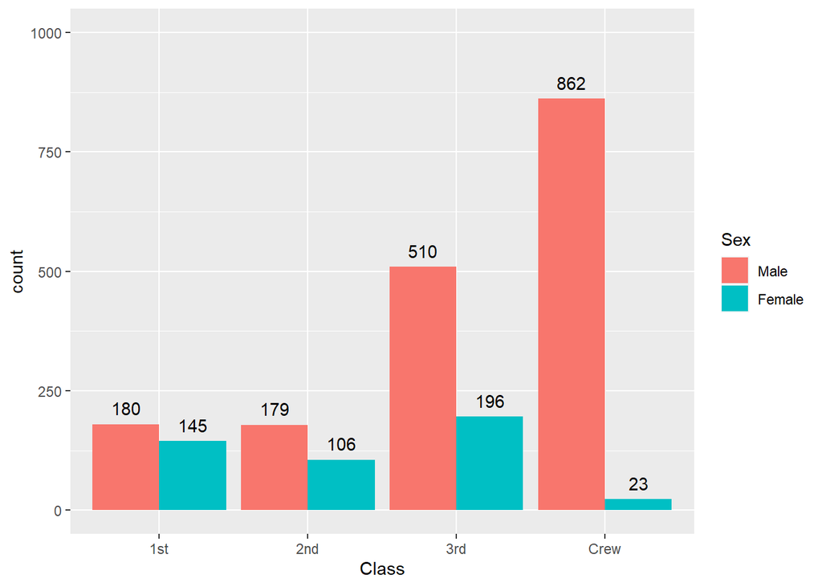

```r
Titanic %>% data.frame() %>%
  group_by(Class, Sex ) %>%
  summarise(count = sum(Freq)) %>%
  ggplot(aes(x=Class , y=count , fill = Sex, label=count)) +
  geom_col(position="dodge") +
  geom_text(position=position_dodge(width=0.9) , vjust=-0.7) +
  ylim(0,1000)
```

## Labels at the end of the plot

I saw some nice infographics with labels at the right-hand side of a bar chart and wanted to recreate that. I do it here by making a new variable called `label_nudge_distance` which will be equal to the distance from the end of each bar to the position of the label. Since each bar ends at a different point, the value of `label_nudge_distance` is specific to each bar. I set it as the maximum value of `count` minus the current value of `count`, plus an extra value of 50 so that the text doesn’t sit right on top of the end of the largest bar, and this value of 50 was found through trial and error (maybe you could standardise it by setting it to a percent of the largest bar).

Note that `label_nudge_distance` is specified within `nudge_y` using the `$` operator to extract `label_nudge_distance` from `data_for_plot`, since there is no `aes` mapping function with `geom_text`.

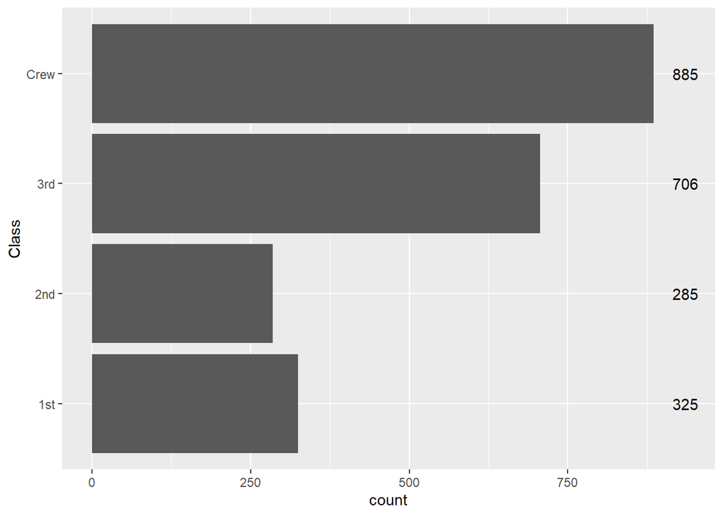

```r
data_for_plot <- Titanic %>% data.frame() %>%
  group_by(Class ) %>%
  summarise(count = sum(Freq)) %>%
  mutate(label_nudge_distance = 50 + max(count)-count)

ggplot(data_for_plot, aes(x=Class , y=count , label=count)) +
  geom_col() +
  coord_flip()+
  geom_text(nudge_y = data_for_plot$label_nudge_distance)
```

Let’s give this plot the Rolls Royce treatment with a couple of adjustments, making the largest category the focus of the plot. We’ll order the bars from largest to smallest using the function `reorder` within the `aes` mapping function for ggplot, with the second argument to this function being `count` indicating how they will be ordered. I’ll set the colour for the bar and label using the variable `bar_label_colour`, which is equal to `darkred` for the largest category and `grey50` for all other categories. I’m making a couple of other changes to the appearance here, using `theme_minimal` to remove a lot of the aesthetic bits like the background colour, then removing gridlines using `panel.grid.major` and `panel.grid.minor` (both are set to `element_blank()`). I’m setting the y-axis text to size 13 and getting rid of the x-axis text altogether (maybe controversial). I’m using `labs` to set the x and y axis labels to an empty string and to give the plot an appropriate title.

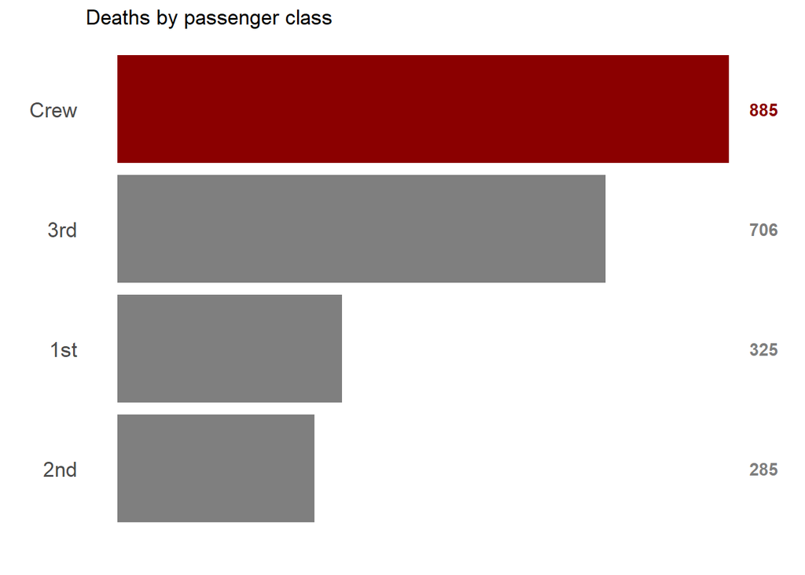

```r
data_for_plot <- Titanic %>% data.frame() %>%
  group_by(Class ) %>%
  summarise(count = sum(Freq)) %>%
  mutate(label_nudge_distance = 50 + max(count)-count) %>%
  mutate(bar_label_colour = if_else(count == max(count), "darkred","grey50"))

ggplot(data_for_plot, aes(x=reorder(Class, count) , y=count , label=count)) +
  geom_col(fill = data_for_plot$bar_label_colour) +
  coord_flip()+
  geom_text(nudge_y = data_for_plot$label_nudge_distance,
            fontface="bold",
            colour = data_for_plot$bar_label_colour) +
  theme_minimal() +
  labs(y = "", x = "" , title = "Deaths by passenger class") +
  theme(panel.grid.major = element_blank(),
        panel.grid.minor = element_blank(),
        axis.text.x = element_blank(),
        axis.text.y = element_text(size=13))
```